# A3_Nguyen_Vu

Vu Nguyen

2024-06-0505

Created June 05 2024 MP

# 1 Task I (87%)

## 1.1 Part 1 (10 points) Code Chunk 1 - Set up, Data import, and Preparation

### 1.1.1 A. Package loading, and data import

#### 1.1.1.1 Package Loading

```r
# Package loading. Install the following packages before running this chunk or knitting this program.
library(C50)
library(knitr)
library(matrixStats)
library(e1071)
library(caret)
```

```r
library(rminer)
library(tictoc)
library(ggplot2)
library(dplyr)
library(rmarkdown)
```

#### 1.1.1.2 Data import

```r
tic()
# use getwd() and setwd() to set the working directory in rmarkdown file
mydir_wd <- getwd()
setwd(mydir_wd)

# Import a csv file
institution <- read.csv(file = "CD_additional_modified.csv", stringsAsFactors = FALSE)
```

#### 1.1.1.3 Summary, Structure before Factor

```r
# examine data before data factorization

str(institution)
```

```
## 'data.frame':    4119 obs. of  21 variables:
##  $ age           : int  30 39 25 38 47 32 32 41 31 35 ...
##  $ job           : chr  "blue-collar" "services" "services" "services" ...
##  $ marital       : chr  "married" "single" "married" "married" ...
##  $ education     : chr  "basic.9y" "high.school" "high.school" "basic.9y" ...
##  $ default       : chr  "no" "no" "no" "no" ...
##  $ housing       : chr  "yes" "no" "yes" "unknown" ...
##  $ loan          : chr  "no" "no" "no" "unknown" ...
##  $ contact       : chr  "cellular" "telephone" "telephone" "telephone" ...
##  $ month         : chr  "may" "may" "jun" "jun" ...
##  $ day_of_week   : chr  "fri" "fri" "wed" "fri" ...
##  $ duration      : int  487 346 227 17 58 128 290 44 68 170 ...
##  $ campaign      : int  2 4 1 3 1 3 4 2 1 1 ...
##  $ pdays         : int  999 999 999 999 999 999 999 999 999 999 ...
##  $ previous      : int  0 0 0 0 0 2 0 0 1 0 ...
##  $ poutcome      : chr  "nonexistent" "nonexistent" "nonexistent" "nonexistent" ...
##  $ emp.var.rate  : num  -1.8 1.1 1.4 1.4 -0.1 -1.1 -1.1 -0.1 -0.1 1.1 ...
##  $ cons.price.idx: num  92.9 94 94.5 94.5 93.2 ...
##  $ cons.conf.idx : num  -46.2 -36.4 -41.8 -41.8 -42 -37.5 -37.5 -42 -42 -36.4 ...
##  $ euribor3m     : num  1.31 4.86 4.96 4.96 4.19 ...
##  $ nr.employed   : num  5099 5191 5228 5228 5196 ...
##  $ y             : chr  "no" "no" "no" "no" ...
```

```r
summary(institution)
```

```
##       age            job              marital           education
##  Min.   :18.00   Length:4119        Length:4119        Length:4119
##  1st Qu.:32.00   Class :character   Class :character   Class :character
##  Median :38.00   Mode  :character   Mode  :character   Mode  :character
##  Mean   :40.11
##  3rd Qu.:47.00
##  Max.   :88.00
##    default            housing              loan             contact
##  Length:4119        Length:4119        Length:4119        Length:4119
##  Class :character   Class :character   Class :character   Class :character
##  Mode  :character   Mode  :character   Mode  :character   Mode  :character
##
##
##
##     month           day_of_week           duration         campaign
##  Length:4119        Length:4119        Min.   :   0.0   Min.   : 1.000
##  Class :character   Class :character   1st Qu.: 103.0   1st Qu.: 1.000
##  Mode  :character   Mode  :character   Median : 181.0   Median : 2.000
##                                        Mean   : 256.8   Mean   : 2.537
##                                        3rd Qu.: 317.0   3rd Qu.: 3.000
##                                        Max.   :3643.0   Max.   :35.000
##      pdays          previous        poutcome          emp.var.rate
##  Min.   :  0.0   Min.   :0.0000   Length:4119        Min.   :-3.40000
##  1st Qu.:999.0   1st Qu.:0.0000   Class :character   1st Qu.:-1.80000
##  Median :999.0   Median :0.0000   Mode  :character   Median : 1.10000
##  Mean   :960.4   Mean   :0.1903                      Mean   : 0.08497
##  3rd Qu.:999.0   3rd Qu.:0.0000                      3rd Qu.: 1.40000
##  Max.   :999.0   Max.   :6.0000                      Max.   : 1.40000
##  cons.price.idx  cons.conf.idx     euribor3m      nr.employed
##  Min.   :92.20   Min.   :-50.8   Min.   :0.635   Min.   :4964
##  1st Qu.:93.08   1st Qu.:-42.7   1st Qu.:1.334   1st Qu.:5099
##  Median :93.75   Median :-41.8   Median :4.857   Median :5191
##  Mean   :93.58   Mean   :-40.5   Mean   :3.621   Mean   :5166
##  3rd Qu.:93.99   3rd Qu.:-36.4   3rd Qu.:4.961   3rd Qu.:5228
##  Max.   :94.77   Max.   :-26.9   Max.   :5.045   Max.   :5228
##       y
##  Length:4119
##  Class :character
##  Mode  :character
##
##
##
```

#### 1.1.1.4 Data Factor

```r
institution$y <- factor(institution$y) # variable y factorization
institution$job <- factor(institution$job) # variable job factorization
institution$education <- factor(institution$education) # variable education factorization
institution$poutcome <- factor(institution$poutcome) # variable poutcome factorization
institution$marital <- factor(institution$marital) # variable marital factorization
institution$default <- factor(institution$default) # variable default factorization
institution$housing <- factor(institution$housing) # variable housing factorization
institution$loan <- factor(institution$loan) # variable loan factorization
institution$contact <- factor(institution$contact) # variable contact factorization
institution$month <- factor(institution$month) #variable month factorization
institution$day_of_week <- factor(institution$day_of_week) #variable day of week factorization
```

#### 1.1.1.5 Summary, Structure after factor

```r
institution %>% str() # show the overall "structure" of data
```

```
## 'data.frame':    4119 obs. of  21 variables:
##  $ age           : int  30 39 25 38 47 32 32 41 31 35 ...
##  $ job           : Factor w/ 12 levels "admin.","blue-collar",..: 2 8 8 8 1 8 1 3 8 2 ...
##  $ marital       : Factor w/ 4 levels "divorced","married",..: 2 3 2 2 2 3 3 2 1 2 ...
##  $ education     : Factor w/ 8 levels "basic.4y","basic.6y",..: 3 4 4 3 7 7 7 7 6 3 ...
##  $ default       : Factor w/ 3 levels "no","unknown",..: 1 1 1 1 1 1 1 2 1 2 ...
##  $ housing       : Factor w/ 3 levels "no","unknown",..: 3 1 3 2 3 1 3 3 1 1 ...
##  $ loan          : Factor w/ 3 levels "no","unknown",..: 1 1 1 2 1 1 1 1 1 1 ...
##  $ contact       : Factor w/ 2 levels "cellular","telephone": 1 2 2 2 1 1 1 1 1 2 ...
##  $ month         : Factor w/ 10 levels "apr","aug","dec",..: 7 7 5 5 8 10 10 8 8 7 ...
##  $ day_of_week   : Factor w/ 5 levels "fri","mon","thu",..: 1 1 5 1 2 3 2 2 4 3 ...
##  $ duration      : int  487 346 227 17 58 128 290 44 68 170 ...
##  $ campaign      : int  2 4 1 3 1 3 4 2 1 1 ...
##  $ pdays         : int  999 999 999 999 999 999 999 999 999 999 ...
##  $ previous      : int  0 0 0 0 0 2 0 0 1 0 ...
##  $ poutcome      : Factor w/ 3 levels "failure","nonexistent",..: 2 2 2 2 2 1 2 2 1 2 ...
##  $ emp.var.rate  : num  -1.8 1.1 1.4 1.4 -0.1 -1.1 -1.1 -0.1 -0.1 1.1 ...
##  $ cons.price.idx: num  92.9 94 94.5 94.5 93.2 ...
##  $ cons.conf.idx : num  -46.2 -36.4 -41.8 -41.8 -42 -37.5 -37.5 -42 -42 -36.4 ...
##  $ euribor3m     : num  1.31 4.86 4.96 4.96 4.19 ...
##  $ nr.employed   : num  5099 5191 5228 5228 5196 ...
##  $ y             : Factor w/ 2 levels "no","yes": 1 1 1 1 1 1 1 1 1 1 ...
```

```r
institution %>% summary() # SUMMARY FUNCTION HERE
```

```
##       age                 job           marital                   education
##  Min.   :18.00   admin.     :1012   divorced: 446   university.degree  :1264
##  1st Qu.:32.00   blue-collar: 884   married :2509   high.school        : 921
##  Median :38.00   technician : 691   single  :1153   basic.9y           : 574
##  Mean   :40.11   services   : 393   unknown :  11   professional.course: 535
##  3rd Qu.:47.00   management : 324                   basic.4y           : 429
##  Max.   :88.00   retired    : 166                   basic.6y           : 228
##                  (Other)    : 649                   (Other)            : 168
##     default        housing          loan           contact         month
##  no     :3315   no     :1839   no     :3349   cellular :2652   may    :1378
##  unknown: 803   unknown: 105   unknown: 105   telephone:1467   jul    : 711
##  yes    :   1   yes    :2175   yes    : 665                    aug    : 636
##                                                                jun    : 530
##                                                                nov    : 446
##                                                                apr    : 215
##                                                                (Other): 203
##  day_of_week    duration         campaign          pdays          previous
##  fri:768     Min.   :   0.0   Min.   : 1.000   Min.   :  0.0   Min.   :0.0000
##  mon:855     1st Qu.: 103.0   1st Qu.: 1.000   1st Qu.:999.0   1st Qu.:0.0000
##  thu:860     Median : 181.0   Median : 2.000   Median :999.0   Median :0.0000
##  tue:841     Mean   : 256.8   Mean   : 2.537   Mean   :960.4   Mean   :0.1903
##  wed:795     3rd Qu.: 317.0   3rd Qu.: 3.000   3rd Qu.:999.0   3rd Qu.:0.0000
##              Max.   :3643.0   Max.   :35.000   Max.   :999.0   Max.   :6.0000
##
##         poutcome     emp.var.rate      cons.price.idx  cons.conf.idx
##  failure    : 454   Min.   :-3.40000   Min.   :92.20   Min.   :-50.8
##  nonexistent:3523   1st Qu.:-1.80000   1st Qu.:93.08   1st Qu.:-42.7
##  success    : 142   Median : 1.10000   Median :93.75   Median :-41.8
##                     Mean   : 0.08497   Mean   :93.58   Mean   :-40.5
##                     3rd Qu.: 1.40000   3rd Qu.:93.99   3rd Qu.:-36.4
##                     Max.   : 1.40000   Max.   :94.77   Max.   :-26.9
##
##    euribor3m      nr.employed     y
##  Min.   :0.635   Min.   :4964   no :3668
##  1st Qu.:1.334   1st Qu.:5099   yes: 451
##  Median :4.857   Median :5191
##  Mean   :3.621   Mean   :5166
##  3rd Qu.:4.961   3rd Qu.:5228
##  Max.   :5.045   Max.   :5228
##
```

### 1.1.2 B. Partition this data frame for simple hold-out evaluation – 70% for training and the other 30% for testing.

```r
set.seed(100)
index_numbers_split <- createDataPartition(institution$y,p=.7,list = FALSE)
train_set <- institution[index_numbers_split,] #partition the 70% to the train set
summary(train_set)
```

```
##       age                 job          marital                   education
##  Min.   :18.00   admin.     :675   divorced: 310   university.degree  :880
##  1st Qu.:32.00   blue-collar:626   married :1754   high.school        :641
##  Median :38.00   technician :490   single  : 811   basic.9y           :422
##  Mean   :40.15   services   :268   unknown :   9   professional.course:378
##  3rd Qu.:47.00   management :239                   basic.4y           :298
##  Max.   :88.00   retired    :120                   basic.6y           :154
##                  (Other)    :466                   (Other)            :111
##     default        housing          loan           contact         month
##  no     :2316   no     :1264   no     :2354   cellular :1872   may    :968
##  unknown: 567   unknown:  67   unknown:  67   telephone:1012   jul    :493
##  yes    :   1   yes    :1553   yes    : 463                    aug    :458
##                                                                jun    :353
##                                                                nov    :318
##                                                                apr    :148
##                                                                (Other):146
##  day_of_week    duration         campaign          pdays          previous
##  fri:552     Min.   :   4.0   Min.   : 1.000   Min.   :  0.0   Min.   :0.0000
##  mon:580     1st Qu.: 103.0   1st Qu.: 1.000   1st Qu.:999.0   1st Qu.:0.0000
##  thu:601     Median : 179.5   Median : 2.000   Median :999.0   Median :0.0000
##  tue:581     Mean   : 256.2   Mean   : 2.544   Mean   :960.8   Mean   :0.1956
##  wed:570     3rd Qu.: 309.0   3rd Qu.: 3.000   3rd Qu.:999.0   3rd Qu.:0.0000
##              Max.   :3253.0   Max.   :29.000   Max.   :999.0   Max.   :6.0000
##
##         poutcome     emp.var.rate      cons.price.idx  cons.conf.idx
##  failure    : 317   Min.   :-3.40000   Min.   :92.20   Min.   :-50.80
##  nonexistent:2469   1st Qu.:-1.80000   1st Qu.:93.08   1st Qu.:-42.70
##  success    :  98   Median : 1.10000   Median :93.44   Median :-41.80
##                     Mean   : 0.07122   Mean   :93.57   Mean   :-40.42
##                     3rd Qu.: 1.40000   3rd Qu.:93.99   3rd Qu.:-36.40
##                     Max.   : 1.40000   Max.   :94.77   Max.   :-26.90
##
##    euribor3m      nr.employed     y
##  Min.   :0.635   Min.   :4964   no :2568
##  1st Qu.:1.334   1st Qu.:5099   yes: 316
##  Median :4.857   Median :5191
##  Mean   :3.611   Mean   :5166
##  3rd Qu.:4.961   3rd Qu.:5228
##  Max.   :5.045   Max.   :5228
##
```

```r
test_set <- institution[-index_numbers_split,] #simply get the rest of the set and make it test set (30% from the 100%)
summary(test_set)
```

```
##       age                   job          marital                  education
##  Min.   :19.00   admin.       :337   divorced:136   university.degree  :384
##  1st Qu.:32.00   blue-collar  :258   married :755   high.school        :280
##  Median :38.00   technician   :201   single  :342   professional.course:157
##  Mean   :40.03   services     :125   unknown :  2   basic.9y           :152
##  3rd Qu.:47.00   management   : 85                  basic.4y           :131
##  Max.   :82.00   self-employed: 47                  basic.6y           : 74
##                  (Other)      :182                  (Other)            : 57
##     default       housing         loan          contact        month
##  no     :999   no     :575   no     :995   cellular :780   may    :410
##  unknown:236   unknown: 38   unknown: 38   telephone:455   jul    :218
##  yes    :  0   yes    :622   yes    :202                   aug    :178
##                                                            jun    :177
##                                                            nov    :128
##                                                            apr    : 67
##                                                            (Other): 57
##  day_of_week    duration         campaign          pdays          previous
##  fri:216     Min.   :   0.0   Min.   : 1.000   Min.   :  0.0   Min.   :0.0000
##  mon:275     1st Qu.: 103.0   1st Qu.: 1.000   1st Qu.:999.0   1st Qu.:0.0000
##  thu:259     Median : 184.0   Median : 2.000   Median :999.0   Median :0.0000
##  tue:260     Mean   : 258.1   Mean   : 2.521   Mean   :959.6   Mean   :0.1781
##  wed:225     3rd Qu.: 329.0   3rd Qu.: 3.000   3rd Qu.:999.0   3rd Qu.:0.0000
##              Max.   :3643.0   Max.   :35.000   Max.   :999.0   Max.   :4.0000
##
##         poutcome     emp.var.rate     cons.price.idx  cons.conf.idx
##  failure    : 137   Min.   :-3.4000   Min.   :92.20   Min.   :-50.80
##  nonexistent:1054   1st Qu.:-1.8000   1st Qu.:93.08   1st Qu.:-42.70
##  success    :  44   Median : 1.1000   Median :93.92   Median :-41.80
##                     Mean   : 0.1171   Mean   :93.61   Mean   :-40.68
##                     3rd Qu.: 1.4000   3rd Qu.:93.99   3rd Qu.:-36.40
##                     Max.   : 1.4000   Max.   :94.77   Max.   :-26.90
##
##    euribor3m      nr.employed     y
##  Min.   :0.643   Min.   :4964   no :1100
##  1st Qu.:1.344   1st Qu.:5099   yes: 135
##  Median :4.857   Median :5191
##  Mean   :3.644   Mean   :5167
##  3rd Qu.:4.961   3rd Qu.:5228
##  Max.   :4.970   Max.   :5228
##
```

### 1.1.3 C. Show the distributions (in percentages) of the target variable in the whole input data frame, the train set and the test set.

```r
#?data.frame
prop.table(table(institution$y)) %>% round(2)*100 # Show the distribution of y in data frame
```

```
##
##  no yes
##  89  11
```

```r
prop.table(table(train_set$y)) %>% round(2)*100 # Show the distribution of y in train set
```

```
##
##  no yes
##  89  11
```

```r
prop.table(table(test_set$y)) %>% round(2)*100 # Show the distribution of y in test set
```

```
##
##  no yes
##  89  11
```

## 1.2 2.(20 points) Code Chunk 2 - Simple Decision Tree Training and Testing

### 1.2.1 A. (10 points) Train a C5.0 model using the default setting. Show information about this model and the summary of the model. Do not plot the tree at this point because the tree might be too complex. Generate and compare this model’s confusion matrices and classification evaluation metrics in testing and training sets

#### 1.2.1.1 Set up the tree

```r
#?C5.0 #?C5.0Control

# here we create models only varying the default
#?C5.0.default
c50_model_default <- C5.0(y ~., train_set)

#summary
summary(c50_model_default)
```

```
##
## Call:
## C5.0.formula(formula = y ~ ., data = train_set)
##
##
## C5.0 [Release 2.07 GPL Edition]      Wed Jun  5 22:11:32 2024
## -------------------------------
##
## Class specified by attribute `outcome'
##
## Read 2884 cases (21 attributes) from undefined.data
##
## Decision tree:
##
## poutcome = success:
## :...nr.employed <= 5017.5: yes (62/11)
## :   nr.employed > 5017.5: no (36/17)
## poutcome in {failure,nonexistent}:
## :...duration > 414:
##     :...nr.employed <= 5076.2: yes (44/14)
##     :   nr.employed > 5076.2:
##     :   :...duration <= 616: no (200/28)
##     :       duration > 616:
##     :       :...job in {housemaid,student,unknown}: yes (7/1)
##     :           job in {retired,unemployed}: no (15/3)
##     :           job = admin.:
##     :           :...duration <= 835: no (19/6)
##     :           :   duration > 835: yes (26/6)
##     :           job = blue-collar:
##     :           :...marital in {divorced,single}: yes (12/3)
##     :           :   marital in {married,unknown}: no (36/14)
##     :           job = management:
##     :           :...euribor3m <= 1.811: yes (2)
##     :           :   euribor3m > 1.811: no (10/2)
##     :           job = self-employed:
##     :           :...previous <= 0: no (3)
##     :           :   previous > 0: yes (2)
##     :           job = services:
##     :           :...day_of_week in {fri,tue,wed}: no (8)
##     :           :   day_of_week in {mon,thu}: yes (7/1)
```

[output cut: 60 more lines]

```
##   81.38% month
##    6.76% job
##    4.96% default
##    3.40% day_of_week
##    2.25% marital
##    2.18% education
##    1.35% age
##    0.55% housing
##    0.45% campaign
##    0.42% euribor3m
##    0.21% cons.conf.idx
##    0.17% previous
##
##
## Time: 0.0 secs
```

```r
#size
c50_model_default$size
```

```
## [1] 38
```

#### 1.2.1.2 Generate Predictions

```r
#?mmetric

# Predict for Train set
tree_cf_train_predictions <- predict(c50_model_default,train_set)
# Predict for Test set
tree_cf_test_predictions <- predict(c50_model_default,test_set)
```

#### 1.2.1.3 Confusion Matrix

```r
# Confusion matrix Train models
  mmetric(train_set$y, tree_cf_train_predictions, metric="CONF")
```

```
## $res
## NULL
##
## $conf
##       pred
## target   no  yes
##    no  2516   52
##    yes  140  176
##
## $roc
## NULL
##
## $lift
## NULL
```

```r
# Confusion matrix Test models
  mmetric(test_set$y, tree_cf_test_predictions, metric="CONF")
```

```
## $res
## NULL
##
## $conf
##       pred
## target   no  yes
##    no  1060   40
##    yes   76   59
##
## $roc
## NULL
##
## $lift
## NULL
```

#### 1.2.1.4 Accuracy, Precision, F1, TPR

```r
# Accuracy, Precision, F1, TPR  for Train
#?mmetric
  mmetric(train_set$y, tree_cf_train_predictions, metric=c("ACC","Precision","F1","TPR"))
```

```
##      ACC      F11      F12     TPR1
## 93.34258 96.32466 64.70588 97.97508
```

```r
# Accuracy, Precision, F1, TPR  for Test

  mmetric(test_set$y, tree_cf_test_predictions, metric=c("ACC","Precision","F1","TPR"))
```

```
##      ACC      F11      F12     TPR1
## 90.60729 94.81216 50.42735 96.36364
```

### 1.2.2 B. (10 points) Explore reducing the tree complexity by lowering CF levels. In the code, select a CF level of your choice to train and test another C5.0 model. Plot the tree. Generate and compare this model’s confusion matrices and classification evaluation metrics in testing and training sets

#### 1.2.2.1 Regenerate the CF value

```r
#?C5.0 #?C5.0Control

# here we create models only varying the default CF (0.25)

c50_model_changed <- C5.0(y ~., train_set, control = C5.0Control(CF=0.001), earlyStopping = FALSE, noGlobalPruning =FALSE)

#summary
summary(c50_model_changed)
```

```
##
## Call:
## C5.0.formula(formula = y ~ ., data = train_set, control = C5.0Control(CF
##  = 0.001), earlyStopping = FALSE, noGlobalPruning = FALSE)
##
##
## C5.0 [Release 2.07 GPL Edition]      Wed Jun  5 22:11:33 2024
## -------------------------------
##
## Class specified by attribute `outcome'
##
## Read 2884 cases (21 attributes) from undefined.data
##
## Decision tree:
##
## poutcome in {failure,nonexistent}: no (2786/248)
## poutcome = success: yes (98/30)
##
##
## Evaluation on training data (2884 cases):
##
##      Decision Tree
##    ----------------
##    Size      Errors
##
##       2  278( 9.6%)   <<
##
##
##     (a)   (b)    <-classified as
##    ----  ----
##    2538    30    (a): class no
##     248    68    (b): class yes
##
##
##  Attribute usage:
##
##  100.00% poutcome
##
##
## Time: 0.0 secs
```

```r
#size
c50_model_changed$size
```

```
## [1] 2
```

#### 1.2.2.2 Plot the tree

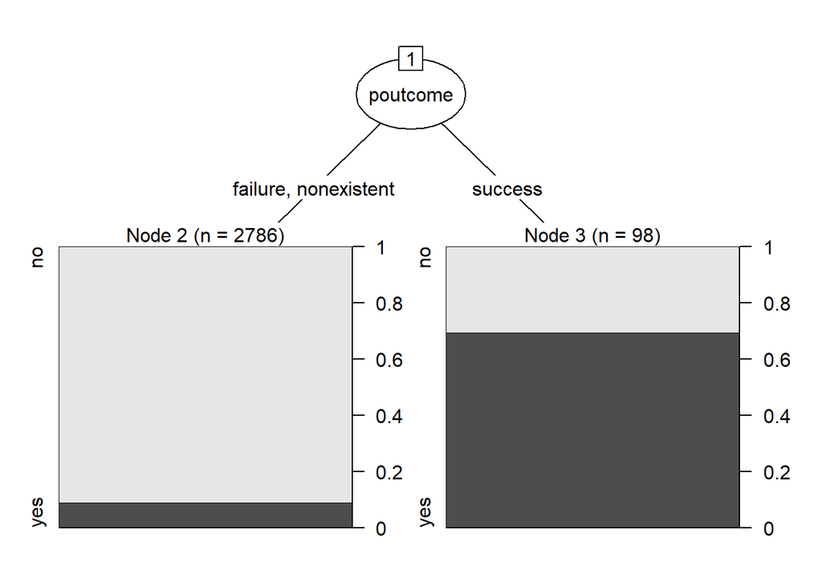

```r
plot(c50_model_changed, fig.height=8, fig.width=20)
```

#### Generate Predictions

```r
#?mmetric

# Predict for Train set
tree_cf_train_predictions <- predict(c50_model_changed,train_set)

# Predict for Test set
tree_cf_test_predictions <- predict(c50_model_changed,test_set)
```

#### 1.2.2.3 Confusion Matrix

```r
# Confusion matrix Train models
  mmetric(train_set$y, tree_cf_train_predictions, metric="CONF")
```

```
## $res
## NULL
##
## $conf
##       pred
## target   no  yes
##    no  2538   30
##    yes  248   68
##
## $roc
## NULL
##
## $lift
## NULL
```

```r
# Confusion matrix Test models
  mmetric(test_set$y, tree_cf_test_predictions, metric="CONF")
```

```
## $res
## NULL
##
## $conf
##       pred
## target   no  yes
##    no  1080   20
##    yes  111   24
##
## $roc
## NULL
##
## $lift
## NULL
```

#### 1.2.2.4 Accuracy, Precision, F1, True Positive Rate

```r
# Accuracy, Precision, F1, True Positive Rate for Train
  mmetric(train_set$y, tree_cf_train_predictions, metric=c("ACC","Precision","F1","TPR"))
```

```
##      ACC      F11      F12     TPR1
## 90.36061 94.80762 32.85024 98.83178
```

```r
# Accuracy, Precision, F1, True Positive Rate for Test
  mmetric(test_set$y, tree_cf_test_predictions, metric=c("ACC","Precision","F1","TPR"))
```

```
##      ACC      F11      F12     TPR1
## 89.39271 94.28197 26.81564 98.18182
```

## 1.3 3.(30 points) Code Chunk 3 - Simple Naïve Bayes Model Training and Testing

### 1.3.1 A. (15 points) Train a naive Bayes model using the training set from 1. Show information about this model. Generate and compare this model’s confusion matrices and classification evaluation metrics in testing and training sets

#### 1.3.1.1 Model1 = w1 NB model all columns; building using e1071 package

```r
# e1071 includes a naiveBayes algorithm to build a Naive Bayesian classification model
# e1071 documentation - https://cran.r-project.org/web/packages/e1071/e1071.pdf

# Run ?naiveBayes to find out more information about naiveBayes

institution_w1_nb <- naiveBayes(y ~., data= train_set)

institution_w1_nb # show model
```

```
##
## Naive Bayes Classifier for Discrete Predictors
##
## Call:
## naiveBayes.default(x = X, y = Y, laplace = laplace)
##
## A-priori probabilities:
## Y
##      no     yes
## 0.89043 0.10957
##
## Conditional probabilities:
##      age
## Y         [,1]      [,2]
##   no  39.84229  9.847911
##   yes 42.64557 13.676338
##
##      job
## Y          admin. blue-collar entrepreneur   housemaid  management     retired
##   no  0.230140187 0.227803738  0.040887850 0.027647975 0.084501558 0.035046729
##   yes 0.265822785 0.129746835  0.022151899 0.018987342 0.069620253 0.094936709
##      job
## Y     self-employed    services     student  technician  unemployed     unknown
##   no    0.039330218 0.095015576 0.017133956 0.166666667 0.024922118 0.010903427
##   yes   0.034810127 0.075949367 0.037974684 0.196202532 0.044303797 0.009493671
##
##      marital
## Y        divorced     married      single     unknown
##   no  0.109034268 0.615264798 0.272585670 0.003115265
##   yes 0.094936709 0.550632911 0.351265823 0.003164557
##
##      education
## Y       basic.4y   basic.6y   basic.9y high.school illiterate
##   no  0.10630841 0.05529595 0.15109034  0.22157321 0.00000000
##   yes 0.07911392 0.03797468 0.10759494  0.22784810 0.00000000
##      education
## Y     professional.course university.degree    unknown
##   no           0.12772586        0.30140187 0.03660436
##   yes          0.15822785        0.33544304 0.05379747
##
```

[output cut: 68 more lines]

```
##
##      cons.conf.idx
## Y          [,1]     [,2]
##   no  -40.54408 4.416817
##   yes -39.43766 5.868128
##
##      euribor3m
## Y         [,1]     [,2]
##   no  3.788662 1.645803
##   yes 2.171699 1.787961
##
##      nr.employed
## Y         [,1]     [,2]
##   no  5174.967 65.99472
##   yes 5094.490 90.89233
```

#### 1.3.1.2 Generate Predictions

```r
#?mmetric

# Predict for Train set with NB institution
nb1_train_predictions <- predict(institution_w1_nb,train_set)

# Predict for Test set with NB institution
nb1_test_predictions <- predict(institution_w1_nb,test_set)
```

#### 1.3.1.3 Generate Data Frame that compare Confusion matrix and classification evaluation with training and test matrix

```r
nb1_train_cf <- mmetric(train_set$y, nb1_train_predictions, metric="CONF") # confusion matrix for training
nb1_train_cf # show confusion matrix
```

```
## $res
## NULL
##
## $conf
##       pred
## target   no  yes
##    no  2336  232
##    yes  122  194
##
## $roc
## NULL
##
## $lift
## NULL
```

```r
nb1_train_evaluation <- mmetric(train_set$y, nb1_train_predictions, metric=c("ACC","F1","PRECISION","TPR")) # evaluation for training
nb1_test_cf <- mmetric(test_set$y, nb1_test_predictions, metric="CONF") # confusion matrix for testing
nb1_test_cf #show confusion matrix
```

```
## $res
## NULL
##
## $conf
##       pred
## target   no  yes
##    no  1003   97
##    yes   60   75
##
## $roc
## NULL
##
## $lift
## NULL
```

```r
nb1_test_evaluation <- mmetric(test_set$y, nb1_test_predictions, metric=c("ACC","F1","PRECISION","TPR")) # evaluation for testing
train_test_nb1_evaluation <- data.frame(nb1_train_evaluation, nb1_test_evaluation)# dataframe of those aspect
train_test_nb1_evaluation
```

```
##            nb1_train_evaluation nb1_test_evaluation
## ACC                    87.72538            87.28745
## F11                    92.95663            92.74156
## F12                    52.29111            48.85993
## PRECISION1             95.03662            94.35560
## PRECISION2             45.53991            43.60465
## TPR1                   90.96573            91.18182
## TPR2                   61.39241            55.55556
```

### 1.3.2 B. (15 points) Explore removing one predictor for building naive Bayes models for this requirement so as to exam the impact of the removal of a predictor. In the code, decide on which predictor to be removed from the data sets for training and testing another naive Bayes model that could improve the true positive rate of the “yes” class of the target variable y. Train and apply this new model. Generate and compare this model’s confusion matrices and classification evaluation metrics in testing and training sets

#### 1.3.2.1 Model2 = w1 model without previous column

```r
# An alternative naiveBayes call to build the same model.
# The 1st argument in naiveBayes() specifies the predictors to be used.
# The 2nd argument indicates the target variable.
# Let's remove previous
#?naiveBayes
institution_w2_nb <- naiveBayes(y ~ age + job + marital + education + default + housing + loan + contact + month + day_of_week + duration + campaign + pdays + poutcome + emp.var.rate + cons.price.idx + cons.conf.idx + euribor3m + nr.employed, data=train_set)
institution_w2_nb
```

```
##
## Naive Bayes Classifier for Discrete Predictors
##
## Call:
## naiveBayes.default(x = X, y = Y, laplace = laplace)
##
## A-priori probabilities:
## Y
##      no     yes
## 0.89043 0.10957
##
## Conditional probabilities:
##      age
## Y         [,1]      [,2]
##   no  39.84229  9.847911
##   yes 42.64557 13.676338
##
##      job
## Y          admin. blue-collar entrepreneur   housemaid  management     retired
##   no  0.230140187 0.227803738  0.040887850 0.027647975 0.084501558 0.035046729
##   yes 0.265822785 0.129746835  0.022151899 0.018987342 0.069620253 0.094936709
##      job
## Y     self-employed    services     student  technician  unemployed     unknown
##   no    0.039330218 0.095015576 0.017133956 0.166666667 0.024922118 0.010903427
##   yes   0.034810127 0.075949367 0.037974684 0.196202532 0.044303797 0.009493671
##
##      marital
## Y        divorced     married      single     unknown
##   no  0.109034268 0.615264798 0.272585670 0.003115265
##   yes 0.094936709 0.550632911 0.351265823 0.003164557
##
##      education
## Y       basic.4y   basic.6y   basic.9y high.school illiterate
##   no  0.10630841 0.05529595 0.15109034  0.22157321 0.00000000
##   yes 0.07911392 0.03797468 0.10759494  0.22784810 0.00000000
##      education
## Y     professional.course university.degree    unknown
##   no           0.12772586        0.30140187 0.03660436
##   yes          0.15822785        0.33544304 0.05379747
##
```

[output cut: 63 more lines]

```
##
##      cons.conf.idx
## Y          [,1]     [,2]
##   no  -40.54408 4.416817
##   yes -39.43766 5.868128
##
##      euribor3m
## Y         [,1]     [,2]
##   no  3.788662 1.645803
##   yes 2.171699 1.787961
##
##      nr.employed
## Y         [,1]     [,2]
##   no  5174.967 65.99472
##   yes 5094.490 90.89233
```

#### 1.3.2.2 Generate Predictions

```r
#?mmetric

# Predict for Train set with NB institution
nb2_train_predictions <- predict(institution_w2_nb,train_set)

# Predict for Test set with NB institution
nb2_test_predictions <- predict(institution_w2_nb,test_set)
```

#### 1.3.2.3 Generate Data Frame that compare Confusion matrix and classification evaluation with training and test matrix

```r
nb2_train_cf <- mmetric(train_set$y, nb2_train_predictions, metric="CONF") # confusion matrix for training
nb2_train_cf # show confusion matrix
```

```
## $res
## NULL
##
## $conf
##       pred
## target   no  yes
##    no  2327  241
##    yes  110  206
##
## $roc
## NULL
##
## $lift
## NULL
```

```r
nb2_train_evaluation <- mmetric(train_set$y, nb2_train_predictions, metric=c("ACC","F1","PRECISION","TPR")) # evaluation for training
nb2_test_cf <- mmetric(test_set$y, nb2_test_predictions, metric="CONF") # confusion matrix for testing
nb2_test_cf #show confusion matrix
```

```
## $res
## NULL
##
## $conf
##       pred
## target   no  yes
##    no  1002   98
##    yes   54   81
##
## $roc
## NULL
##
## $lift
## NULL
```

```r
nb2_test_evaluation <- mmetric(test_set$y, nb2_test_predictions, metric=c("ACC","F1","PRECISION","TPR")) # evaluation for testing
train_test_nb2_evaluation <- data.frame(nb2_train_evaluation, nb2_test_evaluation)# dataframe of those aspect
train_test_nb2_evaluation
```

```
##            nb2_train_evaluation nb2_test_evaluation
## ACC                    87.82940            87.69231
## F11                    92.98701            92.94991
## F12                    53.99738            51.59236
## PRECISION1             95.48625            94.88636
## PRECISION2             46.08501            45.25140
## TPR1                   90.61526            91.09091
## TPR2                   65.18987            60.00000
```

## 1.4 4. (10 points) Code Chunk 4 - Create a Named Cross-validation Function – cv_function ( you can reuse the cv_function in week 3’s tutorial, e.g., CV Titanic Tutorial.Rmd Download CV Titanic Tutorial.Rmd)

A. This function uses several arguments – a data frame, the target variable, classification algorithm, seed value, the number of folds, and a set of classification metrics (without including confusion matrix output). B. It generates and displays the overall accuracy, and precision, true positive rate and f-measure of each class of the target variable of the model built for each fold. C. The function should also generate the mean values and standard deviations of each performance metric over all of the folds. D. Use kable() to show the performance metrics by fold and their mean values and standard deviations.

```r
# create a callable cv_function with input arguments for re-use with different input arguments

cv_function <- function(df, target, nFolds, seedVal, classification, metrics_list)
{
  set.seed(seedVal)
  folds = createFolds(df[,target],nFolds)

  cv_results <- lapply(folds, function(x)
  {
    train <- df[-x,-target]
    test  <- df[x,-target]

    train_target <- df[-x,target]
    test_target <- df[x,target]

    classification_model <- classification(train,train_target)

    pred<- predict(classification_model,test)

    return(mmetric(test_target,pred,c("ACC","PRECISION","TPR","F1")))

  })

  cv_results_m <- as.matrix(as.data.frame(cv_results))

  cv_mean<- as.matrix(rowMeans(cv_results_m))

  colnames(cv_mean) <- "Mean"

  cv_sd <- as.matrix(rowSds(cv_results_m))

  colnames(cv_sd) <- "Sd"

  cv_all <- cbind(cv_results_m, cv_mean, cv_sd)

  kable(cv_all,digits=2)
}
```

## 1.5 5. (20 points) Code Chunk 5 - 5-fold and 10-fold C5.0 and naive Bayes evaluation performance with cv_function ( you can use the cv_function from the tutorial code)

```r
df <- institution
target <- 21
nFolds <- 5
seedVal <- 500
assign("classification", C5.0)
metrics_list <- c("ACC","PRECISION","TPR","F1")
cv_function(df, target, nFolds, seedVal, classification, metrics_list)
```

|  | Fold1 | Fold2 | Fold3 | Fold4 | Fold5 | Mean | Sd |
| --- | --- | --- | --- | --- | --- | --- | --- |
| ACC | 91.63 | 90.05 | 89.44 | 89.79 | 91.87 | 90.56 | 1.11 |
| PRECISION1 | 94.04 | 93.57 | 93.66 | 92.42 | 94.53 | 93.64 | 0.78 |
| PRECISION2 | 65.22 | 55.84 | 51.81 | 55.17 | 65.33 | 58.67 | 6.22 |
| TPR1 | 96.73 | 95.36 | 94.55 | 96.45 | 96.46 | 95.91 | 0.92 |
| TPR2 | 50.00 | 47.25 | 47.78 | 35.56 | 54.44 | 47.01 | 7.00 |
| F11 | 95.37 | 94.46 | 94.10 | 94.39 | 95.48 | 94.76 | 0.62 |
| F12 | 56.60 | 51.19 | 49.71 | 43.24 | 59.39 | 52.03 | 6.29 |

### 1.5.1 NaiveBayes 5-fold

```r
df <- institution
target <- 21
nFolds <- 5
seedVal <- 500
assign("classification", naiveBayes)
metrics_list <- c("ACC","PRECISION","TPR","F1")
cv_function(df, target, nFolds, seedVal, classification, metrics_list)
```

|  | Fold1 | Fold2 | Fold3 | Fold4 | Fold5 | Mean | Sd |
| --- | --- | --- | --- | --- | --- | --- | --- |
| ACC | 86.53 | 87.50 | 84.83 | 87.85 | 88.35 | 87.01 | 1.39 |
| PRECISION1 | 93.57 | 95.13 | 95.38 | 95.41 | 95.18 | 94.93 | 0.77 |
| PRECISION2 | 40.37 | 45.24 | 38.56 | 46.03 | 47.46 | 43.53 | 3.85 |
| TPR1 | 91.14 | 90.59 | 87.19 | 90.72 | 91.55 | 90.24 | 1.74 |
| TPR2 | 48.89 | 62.64 | 65.56 | 64.44 | 62.22 | 60.75 | 6.77 |
| F11 | 92.34 | 92.80 | 91.10 | 93.01 | 93.33 | 92.52 | 0.87 |
| F12 | 44.22 | 52.53 | 48.56 | 53.70 | 53.85 | 50.57 | 4.15 |

#### 1.5.1.1 C5.0 10-folds

```r
df <- institution
target <- 21
nFolds <- 10
seedVal <- 500
assign("classification", C5.0)
metrics_list <- c("ACC","PRECISION","TPR","F1")
cv_function(df, target, nFolds, seedVal, classification, metrics_list)
```

|  | Fold01 | Fold02 | Fold03 | Fold04 | Fold05 | Fold06 | Fold07 | Fold08 | Fold09 | Fold10 | Mean | Sd |
| --- | --- | --- | --- | --- | --- | --- | --- | --- | --- | --- | --- | --- |
| ACC | 90.78 | 90.29 | 88.81 | 89.56 | 91.02 | 90.05 | 92.48 | 91.75 | 89.83 | 92.46 | 90.70 | 1.23 |
| PRECISION1 | 94.10 | 93.83 | 92.55 | 93.55 | 94.12 | 94.54 | 94.21 | 93.70 | 92.88 | 94.67 | 93.81 | 0.68 |
| PRECISION2 | 58.97 | 56.41 | 48.57 | 52.50 | 60.53 | 54.35 | 71.88 | 67.74 | 55.88 | 69.44 | 59.63 | 7.74 |
| TPR1 | 95.64 | 95.37 | 95.08 | 94.82 | 95.91 | 94.28 | 97.55 | 97.28 | 95.91 | 96.99 | 95.88 | 1.09 |
| TPR2 | 51.11 | 48.89 | 37.78 | 46.67 | 51.11 | 55.56 | 51.11 | 46.67 | 41.30 | 55.56 | 48.57 | 5.71 |
| F11 | 94.86 | 94.59 | 93.80 | 94.18 | 95.01 | 94.41 | 95.85 | 95.45 | 94.37 | 95.82 | 94.83 | 0.70 |
| F12 | 54.76 | 52.38 | 42.50 | 49.41 | 55.42 | 54.95 | 59.74 | 55.26 | 47.50 | 61.73 | 53.37 | 5.70 |

#### 1.5.1.2 naiveBayes 10-folds

```r
df <- institution
target <- 21
nFolds <- 10
seedVal <- 500
assign("classification", naiveBayes)
metrics_list <- c("ACC","PRECISION","TPR","F1")
cv_function(df, target, nFolds, seedVal, classification, metrics_list)
```

|  | Fold01 | Fold02 | Fold03 | Fold04 | Fold05 | Fold06 | Fold07 | Fold08 | Fold09 | Fold10 | Mean | Sd |
| --- | --- | --- | --- | --- | --- | --- | --- | --- | --- | --- | --- | --- |
| ACC | 88.11 | 84.95 | 86.86 | 86.65 | 86.65 | 86.17 | 86.41 | 89.81 | 89.59 | 86.37 | 87.16 | 1.54 |
| PRECISION1 | 94.92 | 93.70 | 94.57 | 94.83 | 94.57 | 94.03 | 94.81 | 96.30 | 97.37 | 94.80 | 94.99 | 1.08 |
| PRECISION2 | 46.55 | 36.51 | 42.62 | 42.19 | 41.94 | 40.00 | 41.54 | 52.46 | 52.11 | 41.54 | 43.75 | 5.13 |
| TPR1 | 91.55 | 89.10 | 90.44 | 89.92 | 90.19 | 90.19 | 89.65 | 92.10 | 90.74 | 89.62 | 90.35 | 0.91 |
| TPR2 | 60.00 | 51.11 | 57.78 | 60.00 | 57.78 | 53.33 | 60.00 | 71.11 | 80.43 | 60.00 | 61.15 | 8.57 |
| F11 | 93.20 | 91.34 | 92.46 | 92.31 | 92.33 | 92.07 | 92.16 | 94.15 | 93.94 | 92.13 | 92.61 | 0.88 |
| F12 | 52.43 | 42.59 | 49.06 | 49.54 | 48.60 | 45.71 | 49.09 | 60.38 | 63.25 | 49.09 | 50.97 | 6.30 |

# 2 Task II: Reflections (5%)

## 2.1 What have you learned from building each of these models and the modeling impact of your adjustments to the hyperparameters or dataset? If you were explaining the results of these models to a supervisor what would you say about them? Attempt to do more than just state facts here, interpret the results. Coding is great, interpretation of output is even more important. Discuss each model. Write at least 150 words.

### 2.1.1 Baseline Model

The baseline Naive Bayes model was trained using all available variables in the institution data set. Evaluating the model on both the training and testing sets showed that it performed reasonably well, with acceptable accuracy, precision, f1, true positive rate. The true positive rate (TPR) for the “yes” class was moderate, indicating that the model was fairly effective at identifying positive instances. This model serves as a benchmark for understanding how well the Naive Bayes algorithm can perform with all features included.

### 2.1.2 Reduced Model

The reduced model excluded “previous” to investigate its impact on model performance. Interestingly, the performance metrics of the reduced model on both the training and testing sets showed that true positive rate (short for TPR) for the “yes” class were comparable to, and in some cases, which is TPR2 the true positive rate has a gap up to 4% compare to the old model(the baseline model). This suggests that “previous” might not have been contributing significant information to the model, and its removal helped streamline the model without sacrificing performance.

### 2.1.3 Insights and Interpretation

1. Feature Importance and Redundancy: The comparable performance of the reduced model highlights that “previous” may be redundant or not particularly informative for predicting the target variable “y”. This insight is valuable as it simplifies the model, reducing complexity without losing predictive power, and may lead to better generalizability.
2. Model Efficiency: Removing less informative features can enhance model efficiency. With fewer predictors, the reduced model is less computationally intensive, which is advantageous for scaling and real-time applications.
3. True Positive Rate (TPR): A critical metric for many classification tasks is the TPR for the “yes” class. The fact that the TPR1 did not significantly drop (less than 1% in both training and testing set ), and even improved at a 4% rate in TPR2 training set(61% to 65% -all rounded ); 5% rate in TPR2 testing set(55% to 60% -all rounded) upon removing “previous” indicates that the model’s ability to correctly identify positive instances remains robust.
4. By averaging the results across multiple folds, cross-validation provides a more stable and robust estimate of model performance. It mitigates the impact of any one train/test split that might be particularly favorable or unfavorable. Typically, cross-validation offers a balance between bias and variance. It uses multiple splits to ensure that all data points are used for both training and testing, reducing the likelihood of overfitting or underfitting. Makes more efficient use of the available data. Every observation is used for both training and validation, which is particularly beneficial when dealing with small datasets.

### 2.1.4 Communication to a Supervisor

If I were explaining these results to a supervisor, I would say:

“After comparing the metrics from the train/test split and cross-validation, it’s evident that cross-validation provides a more robust and reliable estimate of model performance. While the train/test split can give us a quick snapshot, it’s dependent on how the data is divided, which might not always be representative of the overall dataset. Cross-validation, on the other hand, averages the performance across multiple splits, reducing the impact of outliers or anomalies in a single split. This method is particularly valuable for ensuring that our model generalizes well to unseen data, making it a preferable choice, especially when dealing with small datasets or when seeking a more dependable assessment of our model’s performance.”

By focusing on these key points, the supervisor would understand not just the technical results but also the practical implications and benefits of the adjustments made during the modeling process.

## 2.2 Additional questions:

### 2.2.1 1. Consider the model that had worse performance, do you think that model would have a scenario where it would be preferred? What might that look like?

- Based on the results, if we assume the baseline model (including all predictors) performed slightly worse than the reduced model (excluding “previous”), it is important to analyze if there might be scenarios where the baseline model would be preferred despite its relatively worse performance.

### 2.2.3 3. Compare the metrics generated by the CV function and your train/test split. Were they different? Do you think one testing method is better than the other? Why?

- Cross-Validation: By averaging the results across multiple folds, cross-validation provides a more stable and robust estimate of model performance. It mitigates the impact of any one train/test split that might be particularly favorable or unfavorable. Typically, cross-validation offers a balance between bias and variance. It uses multiple splits to ensure that all data points are used for both training and testing, reducing the likelihood of overfitting or underfitting. Makes more efficient use of the available data. Every observation is used for both training and validation, which is particularly beneficial when dealing with small datasets.
- Train/Test Split: The results are dependent on the specific split of the data, which might not be representative of the overall dataset.This method can be more prone to variance, as the model’s performance may vary significantly depending on how the data is split. It might not adequately capture the model’s ability to generalize if the test set is not representative.Only part of the data is used for training and another part for testing, which might not be optimal, especially for small datasets.